# Statistics and Predictive Analytics, Lab 5

Swati Singh

```r
# Load packages
library(tidyverse)
library(caret)
library(arm)
library(MASS)
library(missForest)
library(dplyr)
```

### Introduction

In the lecture and tutorial videos we have discussed regularization and introduced logistic regression. This lab will give you practice working with both methods, and will give you a chance to review other important techniques such as missing data imputation, cross-validation, and communicating key results.

### Cleaning and imputing missing data

We will start out working with the “college.csv” dataset in the folder for Lab 5. This dataset consists in statistics for a large number of US Colleges from the 1995 issue of US News and World Report. The outcome variable is “Apps”—the number of annual applications received by the college. One of the challenges in using this dataset is that it contains missing observations that are best imputed. The dataset also has some evident data errors. As noted in the videos, it makes sense to clean the data first (and remove the names of the colleges since that variable, with a different value for every row, will be of no assistance in predicting the number of applications a college receives), then impute the missings.

```r
c <- read.csv("college.csv")
names(c)[1] <- "college"
#You can find a description of the dataset here:
library(ISLR)
?College
```

**Question 1**: Clean the data. Think of logical checks for variable values, for example, after summarizing the data. If you encounter values that are not possible, then remove those rows. (Another option, if there were large numbers of mistaken values, would be to turn them into NAs and impute them.) The dataset contains 777 rows. I was able to find 5 erroneous observations, bringing the number of rows down to 772. See if you can do the same. Please indicate which variables you have cleaned and why.

```r
# Your code goes here
c['college']<-NULL
summary(c)
```

```
 Private         Apps           Accept          Enroll       Top10perc       Top25perc
 No  :209   Min.   :  -20   Min.   :   72   Min.   :  35   Min.   : 1.00   Min.   :  9.0
 Yes :563   1st Qu.:  765   1st Qu.:  604   1st Qu.: 242   1st Qu.:15.00   1st Qu.: 41.0
 NA's:  5   Median : 1557   Median : 1110   Median : 434   Median :23.00   Median : 54.0
            Mean   : 2992   Mean   : 2019   Mean   : 780   Mean   :27.56   Mean   : 55.8
            3rd Qu.: 3624   3rd Qu.: 2424   3rd Qu.: 902   3rd Qu.:35.00   3rd Qu.: 69.0
            Max.   :48094   Max.   :26330   Max.   :6392   Max.   :96.00   Max.   :100.0

  F.Undergrad     P.Undergrad         Outstate       Room.Board       Books
 Min.   :  139   Min.   :    1.0   Min.   : 2340   Min.   :1780   Min.   :  96.0
 1st Qu.:  992   1st Qu.:   95.0   1st Qu.: 7320   1st Qu.:3597   1st Qu.: 470.0
 Median : 1707   Median :  353.0   Median : 9990   Median :4200   Median : 500.0
 Mean   : 3700   Mean   :  855.3   Mean   :10441   Mean   :4358   Mean   : 549.4
 3rd Qu.: 4005   3rd Qu.:  967.0   3rd Qu.:12925   3rd Qu.:5050   3rd Qu.: 600.0
 Max.   :31643   Max.   :21836.0   Max.   :21700   Max.   :8124   Max.   :2340.0

    Personal         PhD            Terminal       S.F.Ratio      perc.alumni
 Min.   : 250   Min.   :  8.00   Min.   : 24.0   Min.   : 2.50   Min.   : 0.00
 1st Qu.: 850   1st Qu.: 62.00   1st Qu.: 71.0   1st Qu.:11.50   1st Qu.:13.00
 Median :1200   Median : 75.00   Median : 82.0   Median :13.60   Median :21.00
 Mean   :1338   Mean   : 72.66   Mean   : 79.7   Mean   :14.09   Mean   :22.74
 3rd Qu.:1682   3rd Qu.: 85.00   3rd Qu.: 92.0   3rd Qu.:16.50   3rd Qu.:31.00
 Max.   :6800   Max.   :103.00   Max.   :100.0   Max.   :39.80   Max.   :64.00
 NA's   :5
     Expend        Grad.Rate
 Min.   : 3186   Min.   : 10.00
 1st Qu.: 6756   1st Qu.: 53.00
 Median : 8408   Median : 65.00
 Mean   : 9673   Mean   : 65.46
 3rd Qu.:10866   3rd Qu.: 78.00
 Max.   :56233   Max.   :118.00
 NA's   :5
```

```r
#Some applications have negative value. This is not realistic as students were enrolled.
c<-c%>%
  filter(Apps>0)
summary(c)
```

```
 Private         Apps           Accept            Enroll         Top10perc
 No  :208   Min.   :   81   Min.   :   72.0   Min.   :  35.0   Min.   : 1.0
 Yes :561   1st Qu.:  777   1st Qu.:  601.8   1st Qu.: 242.0   1st Qu.:15.0
 NA's:  5   Median : 1558   Median : 1110.0   Median : 435.5   Median :23.0
            Mean   : 3003   Mean   : 2021.8   Mean   : 780.8   Mean   :27.5
            3rd Qu.: 3640   3rd Qu.: 2436.0   3rd Qu.: 899.2   3rd Qu.:35.0
            Max.   :48094   Max.   :26330.0   Max.   :6392.0   Max.   :96.0

   Top25perc       F.Undergrad     P.Undergrad          Outstate       Room.Board
 Min.   :  9.00   Min.   :  139   Min.   :    1.00   Min.   : 2340   Min.   :1780
 1st Qu.: 41.00   1st Qu.:  989   1st Qu.:   95.75   1st Qu.: 7326   1st Qu.:3597
 Median : 54.00   Median : 1708   Median :  354.00   Median : 9990   Median :4200
 Mean   : 55.74   Mean   : 3706   Mean   :  856.59   Mean   :10439   Mean   :4357
 3rd Qu.: 69.00   3rd Qu.: 3993   3rd Qu.:  966.00   3rd Qu.:12919   3rd Qu.:5050
 Max.   :100.00   Max.   :31643   Max.   :21836.00   Max.   :21700   Max.   :8124

     Books           Personal         PhD            Terminal        S.F.Ratio
 Min.   :  96.0   Min.   : 250   Min.   :  8.00   Min.   : 24.00   Min.   : 2.50
 1st Qu.: 468.5   1st Qu.: 850   1st Qu.: 62.00   1st Qu.: 71.00   1st Qu.:11.50
 Median : 500.0   Median :1200   Median : 75.00   Median : 82.00   Median :13.60
 Mean   : 548.2   Mean   :1338   Mean   : 72.65   Mean   : 79.71   Mean   :14.08
 3rd Qu.: 600.0   3rd Qu.:1680   3rd Qu.: 85.00   3rd Qu.: 92.00   3rd Qu.:16.50
 Max.   :2340.0   Max.   :6800   Max.   :103.00   Max.   :100.00   Max.   :39.80
                  NA's   :5
  perc.alumni        Expend        Grad.Rate
 Min.   : 0.00   Min.   : 3186   Min.   : 10.00
 1st Qu.:13.00   1st Qu.: 6757   1st Qu.: 53.00
 Median :21.00   Median : 8409   Median : 65.00
 Mean   :22.72   Mean   : 9669   Mean   : 65.48
 3rd Qu.:31.00   3rd Qu.:10864   3rd Qu.: 78.00
 Max.   :64.00   Max.   :56233   Max.   :118.00
                 NA's   :5
```

```r
#Pct columns: Top10perc, Top25perc,PhD, Terminal,perc.alumni, Grad.Rate
#Ensure these are within 0-100. From summary we can see, PhD and Grad.Rate is not. Remove these rows
c<-c%>%
  filter(PhD<=100 & Grad.Rate<=100 )
dim(c)
```

```
[1] 772  18
```

> Some applications have negative value. This is not realistic as students were enrolled. Percentage columns: Top10perc, Top25perc,PhD, Terminal,perc.alumni, Grad.Rate Ensure these are within 0-100. From summary we can see, PhD and Grad.Rate is not. Remove these rows

In the tutorial I mentioned that it is a good idea to check for near zero variance predictors, since they typically do not add much to a model, and can produce problems during cross-validation. We will use the `nearZeroVar()` function in caret:

```r
nearZeroVar(c,  names= T)
```

```
character(0)
```

The predictors appear to have enough variance, given the function’s defaults. This function would, if needed, return a vector of problematic columns for removal.

Use missForest to impute missing values. This resulting imputed dataset is the one we will use for subsequent modeling.

```r
set.seed(31)
# Your code for imputing missing data goes here.
c_complete <- missForest(c)$ximp
```

```
  missForest iteration 1 in progress...done!
  missForest iteration 2 in progress...done!
  missForest iteration 3 in progress...done!
  missForest iteration 4 in progress...done!
  missForest iteration 5 in progress...done!
```

As discussed previously, however, there are other options. The caret package has support for imputation, but, as we’ve seen, its imputation functions only handle numeric data. We can make categorical predictors numeric by turning them into what are known as dummy variables. A dummy variable is a binary variable that represents the presence or absence of a given level of a factor or categorical variable; the original variable is thus split into multiple columns. Here is an illustration using the `dummyVars()` function in caret on a subset of the college dataset and displaying just the top rows.

```r
dummyVars("~.", data = c[, 1:2]) %>%
  predict(newdata = c) %>%
  data.frame %>%
  head
```

|  | Private.No | Private.Yes | Apps |
| --- | --- | --- | --- |
| 1 | 0 | 1 | 1660 |
| 2 | 0 | 1 | 2186 |
| 3 | 0 | 1 | 1428 |
| 4 | 0 | 1 | 417 |
| 5 | 0 | 1 | 193 |
| 6 | 0 | 1 | 587 |

Notice that this function takes the Private variable and converts it into a numeric binary variable. For use in a regression, however, we need to make sure that one level in each dummy is missing (this allows us to avoid perfect collinearity and the so-called “dummy variable trap”). Here is the amended code using the `fullRank = T` argument:

```r
dummyVars("~.", data = c[, 1:2], fullRank = T) %>%
  predict(newdata = c) %>%
  data.frame %>%
  head
```

|  | Private.Yes | Apps |
| --- | --- | --- |
| 1 | 1 | 1660 |
| 2 | 1 | 2186 |
| 3 | 1 | 1428 |
| 4 | 1 | 417 |
| 5 | 1 | 193 |
| 6 | 1 | 587 |

Of course, this example is not very interesting because we have merely taken a binary categorical variable and turned it into a numeric binary variable. Still, the example shows what our workflow would be using caret for imputation:

1. Transform categorical variables into dummy variables,
2. Impute missing data,
3. Use the new dataset in regression.

Here is the workflow:

```r
# Create dummies
cdummy <- dummyVars("~.", data = c, fullRank = T) %>%
  predict(newdata = c) %>%
  data.frame
# The imputation stage
cdummy_median <- cdummy %>%
  preProcess(method = "medianImpute") %>%
  predict(newdata = cdummy)
head(cdummy_median)
```

|  | Private.Yes | Apps | Accept | Enroll | Top10perc | Top25perc | F.Undergrad | P.Undergrad | Outstate | Room.Board | Books | Personal | PhD | Terminal | S.F.Ratio | perc.alumni | Expend | Grad.Rate |
| --- | --- | --- | --- | --- | --- | --- | --- | --- | --- | --- | --- | --- | --- | --- | --- | --- | --- | --- |
| 1 | 1 | 1660 | 1232 | 721 | 23 | 52 | 2885 | 537 | 7440 | 3300 | 450 | 2200 | 70 | 78 | 18.1 | 12 | 7041 | 60 |
| 2 | 1 | 2186 | 1924 | 512 | 16 | 29 | 2683 | 1227 | 12280 | 6450 | 750 | 1500 | 29 | 30 | 12.2 | 16 | 10527 | 56 |
| 3 | 1 | 1428 | 1097 | 336 | 22 | 50 | 1036 | 99 | 11250 | 3750 | 400 | 1165 | 53 | 66 | 12.9 | 30 | 8735 | 54 |
| 4 | 1 | 417 | 349 | 137 | 60 | 89 | 510 | 63 | 12960 | 5450 | 450 | 875 | 92 | 97 | 7.7 | 37 | 19016 | 59 |
| 5 | 1 | 193 | 146 | 55 | 16 | 44 | 249 | 869 | 7560 | 4120 | 800 | 1500 | 76 | 72 | 11.9 | 2 | 10922 | 15 |
| 6 | 1 | 587 | 479 | 158 | 38 | 62 | 678 | 41 | 13500 | 3335 | 500 | 675 | 67 | 73 | 9.4 | 11 | 9727 | 55 |

```r
# Or, the imputation stage (using random forest imputation)
cdummy_bag <- cdummy %>%
  preProcess(method = "bagImpute") %>%
  predict(newdata = cdummy)
head(cdummy_bag)
```

|  | Private.Yes | Apps | Accept | Enroll | Top10perc | Top25perc | F.Undergrad | P.Undergrad | Outstate | Room.Board | Books | Personal | PhD | Terminal | S.F.Ratio | perc.alumni | Expend | Grad.Rate |
| --- | --- | --- | --- | --- | --- | --- | --- | --- | --- | --- | --- | --- | --- | --- | --- | --- | --- | --- |
| 1 | 1 | 1660 | 1232 | 721 | 23 | 52 | 2885 | 537 | 7440 | 3300 | 450 | 2200 | 70 | 78 | 18.1 | 12 | 7041 | 60 |
| 2 | 1 | 2186 | 1924 | 512 | 16 | 29 | 2683 | 1227 | 12280 | 6450 | 750 | 1500 | 29 | 30 | 12.2 | 16 | 10527 | 56 |
| 3 | 1 | 1428 | 1097 | 336 | 22 | 50 | 1036 | 99 | 11250 | 3750 | 400 | 1165 | 53 | 66 | 12.9 | 30 | 8735 | 54 |
| 4 | 1 | 417 | 349 | 137 | 60 | 89 | 510 | 63 | 12960 | 5450 | 450 | 875 | 92 | 97 | 7.7 | 37 | 19016 | 59 |
| 5 | 1 | 193 | 146 | 55 | 16 | 44 | 249 | 869 | 7560 | 4120 | 800 | 1500 | 76 | 72 | 11.9 | 2 | 10922 | 15 |
| 6 | 1 | 587 | 479 | 158 | 38 | 62 | 678 | 41 | 13500 | 3335 | 500 | 675 | 67 | 73 | 9.4 | 11 | 9727 | 55 |

```r
# The modeling stage
lm(Apps ~ .,  data = cdummy_bag) %>%
  display
```

```
lm(formula = Apps ~ ., data = cdummy_bag)
            coef.est coef.se
(Intercept) -447.79   410.01
Private.Yes -496.24   138.56
Accept         1.59     0.04
Enroll        -0.89     0.19
Top10perc     49.84     5.59
Top25perc    -14.40     4.49
F.Undergrad    0.06     0.03
P.Undergrad    0.05     0.03
Outstate      -0.09     0.02
Room.Board     0.15     0.05
Books          0.04     0.24
Personal       0.03     0.06
PhD           -9.33     4.70
Terminal      -3.12     5.12
S.F.Ratio     15.05    13.06
perc.alumni    0.17     4.11
Expend         0.08     0.01
Grad.Rate      9.47     2.99
---
n = 772, k = 18
residual sd = 1042.52, R-Squared = 0.93
```

Notice that n = 772. We successfully imputed the missing data, including 5 missing observations in Private.

### Linear regression and regularization

**Question 2**: Fit a regression model of Apps (the number of applications a college receives) using all the predictor variables in the data set. Report the cross-validation estimate of out-of-sample RMSE automatically produced by caret. Use 10-fold cross-validation repeated 5 times to ensure good stability in the estimates. Use 31 as the random seed.

```r
set.seed(31)
# Your code goes here
(lm_caret <- train(Apps ~ .,
      data=c_complete,
      preProcess=c("center","scale"),
      trControl = trainControl(method = "repeatedcv", number = 10, repeats = 5),
      method="lm"))
```

```
Linear Regression

772 samples
 17 predictor

Pre-processing: centered (17), scaled (17)
Resampling: Cross-Validated (10 fold, repeated 5 times)
Summary of sample sizes: 693, 695, 694, 696, 694, 694, ...
Resampling results:

  RMSE      Rsquared   MAE
  1079.243  0.9198551  630.148

Tuning parameter 'intercept' was held constant at a value of TRUE
```

> The cross-validation estimate of out-of-sample RMSE is 1079.2431541

**Question 3**: Fit a regularized regression model of Apps using `glmnet` in caret. Use all the predictor variables, but do not specify a search grid or a particular model (lasso or ridge); let the defaults in glmnet handle these choices. Again, use 10 fold cross validation repeated 5 times.

1. Report estimated out-of-sample RMSE.
2. Report which model type—ridge or lasso or a mixture of the two—was chosen by glmnet.
3. Is there a reason to prefer one of these models— linear regression (question 2) or this regularized model— for prediction?

```r
set.seed(410)
# Your code goes here
(reg_lm<-train(Apps ~ .,
      data=c_complete,
      preProcess=c("center","scale"),
      trControl = trainControl(method = "repeatedcv", number = 10, repeats = 5),
      metric="RMSE",
      method="glmnet"))
```

```
glmnet

772 samples
 17 predictor

Pre-processing: centered (17), scaled (17)
Resampling: Cross-Validated (10 fold, repeated 5 times)
Summary of sample sizes: 696, 696, 695, 695, 694, 694, ...
Resampling results across tuning parameters:

  alpha  lambda      RMSE      Rsquared   MAE
  0.10     7.319107  1089.291  0.9217011  628.8712
  0.10    73.191065  1100.854  0.9223840  619.5567
  0.10   731.910651  1243.868  0.9076546  667.7425
  0.55     7.319107  1090.136  0.9218198  625.5263
  0.55    73.191065  1102.368  0.9212352  607.7861
  0.55   731.910651  1319.263  0.9059202  707.2908
  1.00     7.319107  1090.139  0.9219414  622.4156
  1.00    73.191065  1113.676  0.9181873  610.7180
  1.00   731.910651  1420.557  0.8910369  803.5576

RMSE was used to select the optimal model using the smallest value.
The final values used for the model were alpha = 0.1 and lambda = 7.319107.
```

```r
Tuned_Model_RMSE<-min(reg_lm$results$RMSE)
```

> 1. Report estimated out-of-sample RMSE.:1089.2913787
> 2. The model chose elastic net which is a combination of lasso and ridge. This is because the final model usestwo tuning parameters alpha = 0.1 and lambda = 7.319107. 3.We use regularization methods when we want to add a shrinkage penalty that allows the less contributing variable coefficient to shrink towards zero. In this case, we can see that the R2 has slightly changed when we switched from linear model to regularized model by 0.002 which is a negligible change. Since regaularized model is not contributing substantially in improving our model, we should choose linear regression model for prediction. “Everything should be made simple as possible, but not simpler - Albert Einstein”

**Question 4**: Which predictor had the largest effect size in the linear model (from question 2)?

```r
# Your code goes here
lm_caret$finalModel
```

```
Call:
lm(formula = .outcome ~ ., data = dat)

Coefficients:
(Intercept)   PrivateYes       Accept       Enroll    Top10perc    Top25perc  F.Undergrad
   3005.536     -221.167     3907.241     -827.200      877.045     -284.816      276.417
P.Undergrad     Outstate   Room.Board        Books     Personal          PhD     Terminal
     69.626     -350.656      165.222        6.309       19.293     -151.473      -46.075
  S.F.Ratio  perc.alumni       Expend    Grad.Rate
     59.440        2.248      410.247      161.357
```

> Accept has the largest effect size of abs value 3907 followed by Top10perc and Enroll respectively.

### Statistical communication

**Question 5**: Create and explain a visualization that conveys what you think is the main result from the above—or any additional—modeling.

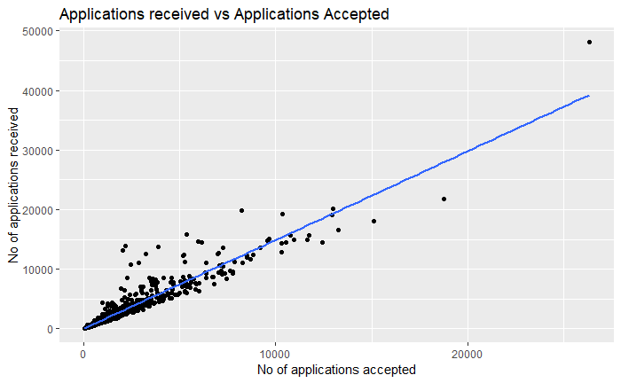

```r
# Your code goes here
par(mfrow=c(2,2))
ggplot(c, aes(x=Accept, y=Apps)) +
    geom_point() +
    geom_smooth(method="lm",
                se=FALSE) +
  labs(x="No of applications accepted",
       y="No of applications received",
       title="Applications received vs Applications Accepted")
```

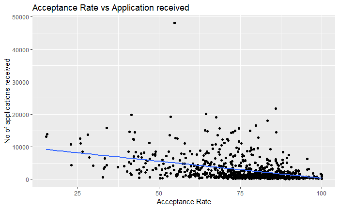

```r
c%>%
  mutate(Acceptance_rate=Accept*100/Apps)%>%
  ggplot(aes(x=Acceptance_rate, y=Apps)) +
    geom_point() +
    geom_smooth(method="lm",
                se=FALSE) +
  labs(x="Acceptance Rate",
       y="No of applications received",
       title="Acceptance Rate vs Application received")
```

> There is strong positive linear relationship between Apps and Accept. With an increase in number of applications accepted, the number of applications increase. However, contradicting this, as the acceptance rate increases, the number of applications decreses. there is a weak negative linear relationship between Acceptance rate and applications received.

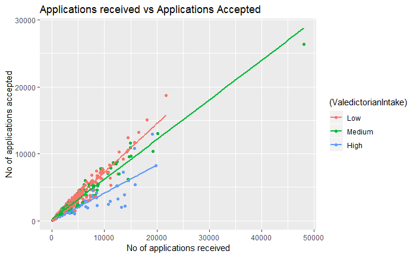

```r
c%>%
  mutate(ValedictorianIntake=cut_interval(Top10perc,n=3,labels=c("Low","Medium","High")))%>%
  ggplot(aes(x=Apps, y=Accept, color=(ValedictorianIntake))) +
  geom_point() +
  geom_smooth(method="lm",   # Add linear regression lines
                se=FALSE) +
  labs(x="No of applications received",
       y="No of applications accepted",
       title="Applications received vs Applications Accepted")
```

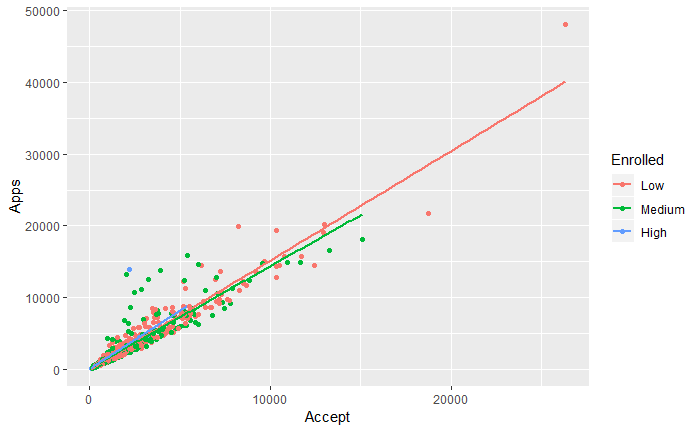

```r
c%>%
  mutate(Enrollment_rate=Enroll*100/Accept,Enrolled=cut_interval(Enrollment_rate,n=3,labels=c("Low","Medium","High")))%>%
  ggplot(aes(x=Accept, y=Apps,color=Enrolled)) +
    geom_point() +
    geom_smooth(method="lm",
                se=FALSE)
```

```r
NA
```

### Logistic regression

Download the Pima dataset from the folder for Lab 5 in Canvas. Is any cleaning necessary? It doesn’t look like it. Impute missing observations using the median of each variable (do not use missForest). Remember to remove the first column, which is just a row number and, as such, useless for modeling.

```r
# Your code  should go here.
p<-read.csv('pima.csv')
p[1]<-NULL
#Check for NA values
colSums(is.na(p))
```

```
npreg   glu    bp  skin   bmi   ped   age  type
    0     0     0     0     0     0     0     0
```

```r
#There is no missing data
#summary(p)
#imputeMissings::impute(p,method = "median/mode")
#head(p)
#summary(p)
```

**Question 6**: Using the cleaned and imputed Pima dataset, fit a model with centered and scaled inputs that predicts type using all the predictors (degrees of freedom = 524). We’ll call this the “full model.” Next, create a new model that includes age as a categorical predictor (binned into quartiles). We’ll call this the “cat model” (for categorical). The easiest way to do bin age is to use the `quantile()` function as an argument within the `cut()` function. Be sure to use `include.lowest = T` as an argument to cut(). It would look something like this, with `x` as the data object: `cut(data$x, quantile(data$x), include.lowest = T)`. Center and scale the predictors in this model. Which of the two models — the one with age as a continuous (full model) or the one with age as a categorical variable (cat model) —is better? Use AIC to answer the question.

```r
# Your code goes here
#Since the target variable is categorical, we use generalized linear model
full_model<-glm(type~npreg+glu+bp+skin+bmi+ped+age,
                data=p,family = "binomial")%>%
  standardize
paste("AIC of full model: " ,full_model$aic)
```

```
[1] "AIC of full model:  482.322267759498"
```

```r
p_age<-p%>%
  mutate(age=cut(age,breaks=quantile(age),include.lowest = T))
cat_model<-glm(type~npreg+glu+bp+skin+bmi+ped+age,data=p_age,family="binomial")%>%standardize
paste("AIC of cat model: " ,cat_model$aic)
```

```
[1] "AIC of cat model:  471.774445883184"
```

> Cat_model has a lower AIC than full model.The model with age as categorical predictor is a better fitting model.AIC is an estimate of a constant plus the relative distance between the unknown true likelihood function of the data and the fitted likelihood function of the model, so that a lower AIC means a model is considered to be closer to the truth.

**Question 7**: Interpret the coefficients for the categorical age variable in the above cat model (522 df) as log odds. You should be interpreting 3 coefficients, plus the intercept. By “interpret” I mean that you should explain the coefficients—the actual numbers in the model output: what do they signify?

```r
summary(cat_model)
```

```
Call:
glm(formula = type ~ z.npreg + z.glu + z.bp + z.skin + z.bmi +
    z.ped + age, family = "binomial", data = p_age)

Deviance Residuals:
    Min       1Q   Median       3Q      Max
-3.1565  -0.6450  -0.3269   0.6394   2.5270

Coefficients:
             Estimate Std. Error z value Pr(>|z|)
(Intercept) -1.989480   0.346205  -5.747 9.11e-09 ***
z.npreg      0.525964   0.304898   1.725 0.084518 .
z.glu        2.189677   0.265944   8.234  < 2e-16 ***
z.bp        -0.254639   0.255071  -0.998 0.318131
z.skin       0.008546   0.310098   0.028 0.978015
z.bmi        1.187941   0.320246   3.709 0.000208 ***
z.ped        0.867498   0.252361   3.438 0.000587 ***
age(23,28]   0.659982   0.400407   1.648 0.099296 .
age(28,38]   1.595741   0.415581   3.840 0.000123 ***
age(38,81]   1.579387   0.488510   3.233 0.001225 **
---
Signif. codes:  0 *** 0.001 ** 0.01 * 0.05 . 0.1   1

(Dispersion parameter for binomial family taken to be 1)

    Null deviance: 676.79  on 531  degrees of freedom
Residual deviance: 451.77  on 522  degrees of freedom
AIC: 471.77

Number of Fisher Scoring iterations: 5
```

> The log odds of having diabetes is -1.99 when all the other variables are averaged at 0 i.e. have no effect on the target variable. The log odds of having diabetes increases by 0.66 if the candidate changes to age group of 23-28 from the intercept level. The log odds of having diabetes increases by 1.60 if the candidate changes to age group of 28-38 from the intercept level. The log odds of having diabetes increases by 1.58 if the candidate changes to age group of 38-81 from the intercept level.

As I said in the video lecture, converting log odds into probabilities can be tricky. With log odds we can get a sense of the relative magnitude of effect sizes (some are bigger than others), or whether an effect is positive or negative. Otherwise, log odds aren’t meaningful. We must translate them into probabilities. We do that using the model equation and the inverse logit function.

For example, to calculate the probability that someone who is average in all the predictors has diabetes we could use the intercept from a centered model. This example uses the above model with categorical age (cat_model). I am using the imputed dataset, which I have titled “p_imp.”

```r
coef(cat_model) # Here are all the coefficients
```

```
 (Intercept)      z.npreg        z.glu         z.bp       z.skin        z.bmi        z.ped
-1.989479947  0.525964286  2.189677013 -0.254639284  0.008545606  1.187940529  0.867498025
  age(23,28]   age(28,38]   age(38,81]
 0.659981803  1.595740817  1.579386703
```

```r
coef(cat_model)[1] # Here is just the intercept
```

```
(Intercept)
   -1.98948
```

```r
# But we have a categorical predictor for age, so we need to find
# the category that contains mean age.
mean(p$age)
```

```
[1] 31.61466
```

```r
# Mean age of 31.6 would be in the third age category or the 9th
# coefficient.
coef(cat_model)[9]
```

```
age(28,38]
  1.595741
```

```r
# Here is the log odds of an average person having diabetes:
coef(cat_model)[1] + coef(cat_model)[9]
```

```
(Intercept)
 -0.3937391
```

```r
# Then we use the invlogit function to wrap the equation and
# transform log odds into a probability :
invlogit <- function(x) exp(x)/(1 + exp(x)) # define the function
invlogit(coef(cat_model)[1] + coef(cat_model)[9]) # wrap the equation
```

```
(Intercept)
  0.4028175
```

```r
# or, the same thing, turning off the coefficients we do not
# want (by multiplying by 0) and turning on the ones we do
# want (by multiplying by 1).
invlogit(coef(cat_model)[1] +
           coef(cat_model)[2]*0 +
           coef(cat_model)[3]*0 +
           coef(cat_model)[4]*0 +
           coef(cat_model)[5]*0 +
           coef(cat_model)[6]*0 +
           coef(cat_model)[7]*0 +
           coef(cat_model)[8]*0 +
           coef(cat_model)[9]*1 +
           coef(cat_model)[10]*0)
```

```
(Intercept)
  0.4028175
```

Thus, according to this model, someone who is average in all respects has a .4 probability of having diabetes.

**Question 8**: Using the same cat model calculate the probability of diabetes for someone who has a scaled BMI of .3 (assuming that scaling has been done by dividing by 2 sd) but who is average in all the other predictors.

```r
# Your code goes here
invlogit(coef(cat_model)[1] +
           coef(cat_model)[2]*0 +
           coef(cat_model)[3]*0 +
           coef(cat_model)[4]*0 +
           coef(cat_model)[5]*0 +
           coef(cat_model)[6]*0.3 +
           coef(cat_model)[7]*0 +
           coef(cat_model)[8]*0 +
           coef(cat_model)[9]*1 +
           coef(cat_model)[10]*0)
```

```
(Intercept)
  0.4906618
```

> The probability of diabetes for an average person with a scaled BMI of .3 is 0.49

**Question 9**: Using the same model, calculate the *change* in the probability of diabetes associated with increasing scaled BMI from 0 (average) to .3 for someone who is average in all the other predictors.

```r
# Your code goes here
q9<-(invlogit(coef(cat_model)[1] +
           coef(cat_model)[2]*0 +
           coef(cat_model)[3]*0 +
           coef(cat_model)[4]*0 +
           coef(cat_model)[5]*0 +
           coef(cat_model)[6]*0.3 +
           coef(cat_model)[7]*0 +
           coef(cat_model)[8]*0 +
           coef(cat_model)[9]*1 +
           coef(cat_model)[10]*0)  -invlogit(coef(cat_model)[1] +
           coef(cat_model)[2]*0 +
           coef(cat_model)[3]*0 +
           coef(cat_model)[4]*0 +
           coef(cat_model)[5]*0 +
           coef(cat_model)[6]*0 +
           coef(cat_model)[7]*0 +
           coef(cat_model)[8]*0 +
           coef(cat_model)[9]*1 +
           coef(cat_model)[10]*0))
q9
```

```
(Intercept)
 0.08784434
```

> The probability increases by 0.0878443